# Business Type Identify and Churn Prediction

## Problem Overview

Stripe currently has user transaction data for the period 1/1/33 to 12/31/34, including the time and amount (in cents) of each transaction. We hope to use this data to gain better insight into merchant behavior, achieve fine-grained operations for different types of merchants and reduce consumer churn.

## Contents

1. Data Processing
2. Exploratory Data Analysis
3. Business Type Identify
4. Churn Prediction
5. Conclusion

```python
##Import the libraries you are going to use
import pandas as pd
import numpy as np
import matplotlib.pyplot as plt
import pandasql as ps
import seaborn as sns
from datetime import datetime
%matplotlib inline
```

```python
data = pd.read_csv('takehome_ds_written.csv')
data.info()
data.head()
# no missing value to cope with
```

```
<class 'pandas.core.frame.DataFrame'>
RangeIndex: 1513719 entries, 0 to 1513718
Data columns (total 4 columns):
 #   Column               Non-Null Count    Dtype
---  ------               --------------    -----
 0   Unnamed: 0           1513719 non-null  int64
 1   merchant             1513719 non-null  object
 2   time                 1513719 non-null  object
 3   amount_usd_in_cents  1513719 non-null  int64
dtypes: int64(2), object(2)
memory usage: 46.2+ MB
```

|  | Unnamed: 0 | merchant | time | amount_usd_in_cents |
| --- | --- | --- | --- | --- |
| 0 | 1 | faa029c6b0 | 2034-06-17 23:34:14 | 6349 |
| 1 | 2 | ed7a7d91aa | 2034-12-27 00:40:38 | 3854 |
| 2 | 3 | 5608f200cf | 2034-04-30 01:29:42 | 789 |
| 3 | 4 | 15b1a0d61e | 2034-09-16 01:06:23 | 4452 |
| 4 | 5 | 4770051790 | 2034-07-22 16:21:42 | 20203 |

```python
# set string time to date type for the calculation later
data['time'] = pd.to_datetime(data['time'])
```

```python
data_agg = data.groupby(data.merchant).agg({'time':[np.max,np.min,'count'],'amount_usd_in_cents':'sum'})
data_agg.columns = data_agg.columns.map(''.join)
data_agg['daydiff'] =((data_agg['timeamax']-data_agg['timeamin']).astype('timedelta64[h]'))/24
data_agg['avg_day'] = data_agg['daydiff']/data_agg['timecount']
data_agg['avg_amount'] = data_agg['amount_usd_in_centssum']/data_agg['timecount']
data_agg['lastbuy'] = ((data_agg['timeamax'].max()-data_agg['timeamax']).astype('timedelta64[h]'))/24

data_agg.head()
```

| merchant | timeamax | timeamin | timecount | amount_usd_in_centssum | daydiff | avg_day | avg_amount | lastbuy |
| --- | --- | --- | --- | --- | --- | --- | --- | --- |
| 0002b63b92 | 2033-05-16 20:07:57 | 2033-05-16 20:07:57 | 1 | 3379 | 0.000000 | 0.000000 | 3379.000000 | 593.458333 |
| 0002d07bba | 2034-12-15 09:56:19 | 2034-10-11 17:02:26 | 4 | 89278 | 64.666667 | 16.166667 | 22319.500000 | 15.916667 |
| 00057d4302 | 2033-08-04 04:26:40 | 2033-05-30 01:30:52 | 28 | 29521 | 66.083333 | 2.360119 | 1054.321429 | 514.125000 |
| 000bcff341 | 2033-08-09 20:18:36 | 2033-08-09 20:18:36 | 1 | 7826 | 0.000000 | 0.000000 | 7826.000000 | 508.458333 |
| 000ddbf0ca | 2033-06-02 13:25:12 | 2033-06-02 13:25:12 | 1 | 10299 | 0.000000 | 0.000000 | 10299.000000 | 576.750000 |

## EDA

```python
data_agg.columns
```

```
Index(['timeamax', 'timeamin', 'timecount', 'amount_usd_in_centssum',
       'daydiff', 'avg_day', 'avg_amount', 'lastbuy'],
      dtype='object')
```

```python
import seaborn as sns
import missingno
import warnings
import matplotlib
warnings.filterwarnings("ignore")


def time_series_plot(df):
    """Given dataframe, generate times series plot of numeric data by daily, monthly and yearly frequency"""
    print("\nTo check time series of numeric data  by daily, monthly and yearly frequency")
    if len(df.select_dtypes(include='datetime64').columns)>0:
        for col in df.select_dtypes(include='datetime64').columns:
            for p in ['D', 'M', 'Y']:
                if p=='D':
                    print("Plotting daily data")
                elif p=='M':
                    print("Plotting monthly data")
                else:
                    print("Plotting yearly data")
                for col_num in df.select_dtypes(include=np.number).columns:
                    __ = df.copy()
                    __ = __.set_index(col)
                    __T = __.resample(p).sum()
                    ax = __T[[col_num]].plot()
                    ax.set_ylim(bottom=0)
                    ax.get_yaxis().set_major_formatter(
                    matplotlib.ticker.FuncFormatter(lambda x, p: format(int(x), ',')))
                    plt.show()


def numeric_eda(df, hue=None):
    """Given dataframe, generate EDA of numeric data"""
    print("\nTo check: \nDistribution of numeric data")
    display(df.describe().T)
    columns = df.select_dtypes(include=np.number).columns
    figure = plt.figure(figsize=(20, 10))
    figure.add_subplot(1, len(columns), 1)
    for index, col in enumerate(columns):
        if index > 0:
            figure.add_subplot(1, len(columns), index + 1)
        sns.boxplot(y=col, data=df, boxprops={'facecolor': 'None'})
    figure.tight_layout()
    plt.show()

    if len(df.select_dtypes(include='category').columns) > 0:
        for col_num in df.select_dtypes(include=np.number).columns:
            for col in df.select_dtypes(include='category').columns:
                fig = sns.catplot(x=col, y=col_num, kind='violin', data=df, height=5, aspect=2)
                fig.set_xticklabels(rotation=90)
                plt.show()

    # Plot the pairwise joint distributions
    print("\nTo check pairwise joint distribution of numeric data")
    if hue==None:
        sns.pairplot(df.select_dtypes(include=np.number))
    else:
        sns.pairplot(df.select_dtypes(include=np.number).join(df[[hue]]), hue=hue)
    plt.show()


def top5(df):
    """Given dataframe, generate top 5 unique values for non-numeric data"""
    columns = df.select_dtypes(include=['object', 'category']).columns
    for col in columns:
        print("Top 5 unique values of " + col)
        print(df[col].value_counts().reset_index().rename(columns={"index": col, col: "Count"})[
              :min(5, len(df[col].value_counts()))])
        print(" ")


def categorical_eda(df, hue=None):
    """Given dataframe, generate EDA of categorical data"""
    print("\nTo check: \nUnique count of non-numeric data\n")
    print(df.select_dtypes(include=['object', 'category']).nunique())
    top5(df)
    # Plot count distribution of categorical data
    for col in df.select_dtypes(include='category').columns:
        fig = sns.catplot(x=col, kind="count", data=df, hue=hue)
        fig.set_xticklabels(rotation=90)
        plt.show()


def eda(df):
    """Given dataframe, generate exploratory data analysis"""
    # check that input is pandas dataframe
    if type(df) != pd.core.frame.DataFrame:
        raise TypeError("Only pandas dataframe is allowed as input")

    # replace field that's entirely space (or empty) with NaN
    df = df.replace(r'^\s*$', np.nan, regex=True)

    print("Preview of data:")
    display(df.head(3))

    print("\nTo check: \n (1) Total number of entries \n (2) Column types \n (3) Any null values\n")
    print(df.info())

    # generate preview of entries with null values
    if df.isnull().any(axis=None):
        print("\nPreview of data with null values:")
        display(df[df.isnull().any(axis=1)].head(3))
        missingno.matrix(df)
        plt.show()

    # generate count statistics of duplicate entries
    if len(df[df.duplicated()]) > 0:
        print("\n***Number of duplicated entries: ", len(df[df.duplicated()]))
        display(df[df.duplicated(keep=False)].sort_values(by=list(df.columns)).head())
    else:
        print("\nNo duplicated entries found")

    # EDA of categorical data
    categorical_eda(df)

    # EDA of numeric data
    numeric_eda(df)

    # Plot time series plot of numeric data
    time_series_plot(df)
```

```
Preview of data:
```

| merchant | timecount | amount_usd_in_centssum | daydiff | avg_day | avg_amount | lastbuy |
| --- | --- | --- | --- | --- | --- | --- |
| 0002b63b92 | 1 | 3379 | 0.000000 | 0.000000 | 3379.000000 | 593.458333 |
| 0002d07bba | 4 | 89278 | 64.666667 | 16.166667 | 22319.500000 | 15.916667 |
| 00057d4302 | 28 | 29521 | 66.083333 | 2.360119 | 1054.321429 | 514.125000 |

```
To check:
 (1) Total number of entries
 (2) Column types
 (3) Any null values

<class 'pandas.core.frame.DataFrame'>
Index: 14351 entries, 0002b63b92 to fff1754102
Data columns (total 6 columns):
 #   Column                  Non-Null Count  Dtype
---  ------                  --------------  -----
 0   timecount               14351 non-null  int64
 1   amount_usd_in_centssum  14351 non-null  int64
 2   daydiff                 14351 non-null  float64
 3   avg_day                 14351 non-null  float64
 4   avg_amount              14351 non-null  float64
 5   lastbuy                 14351 non-null  float64
dtypes: float64(4), int64(2)
memory usage: 784.8+ KB
None

No duplicated entries found

To check:
Unique count of non-numeric data

Series([], dtype: float64)

To check:
Distribution of numeric data
```

|  | count | mean | std | min | 25% | 50% | 75% | max |
| --- | --- | --- | --- | --- | --- | --- | --- | --- |
| timecount | 14351.0 | 1.054783e+02 | 5.277180e+02 | 1.0 | 3.000000 | 11.000000 | 45.000000 | 2.551200e+04 |
| amount_usd_in_centssum | 14351.0 | 1.633296e+06 | 6.431726e+06 | 201.0 | 36263.000000 | 160262.000000 | 823099.500000 | 2.369072e+08 |
| daydiff | 14351.0 | 1.998778e+02 | 2.039058e+02 | 0.0 | 17.854167 | 127.708333 | 348.333333 | 7.284167e+02 |
| avg_day | 14351.0 | 1.420535e+01 | 2.444967e+01 | 0.0 | 0.848783 | 4.994048 | 16.512213 | 3.623333e+02 |
| avg_amount | 14351.0 | 3.810458e+04 | 1.415186e+05 | 201.0 | 5738.181713 | 10965.000000 | 27321.222222 | 8.887465e+06 |
| lastbuy | 14351.0 | 1.367070e+02 | 1.745003e+02 | 0.0 | 9.375000 | 51.291667 | 212.500000 | 7.282500e+02 |

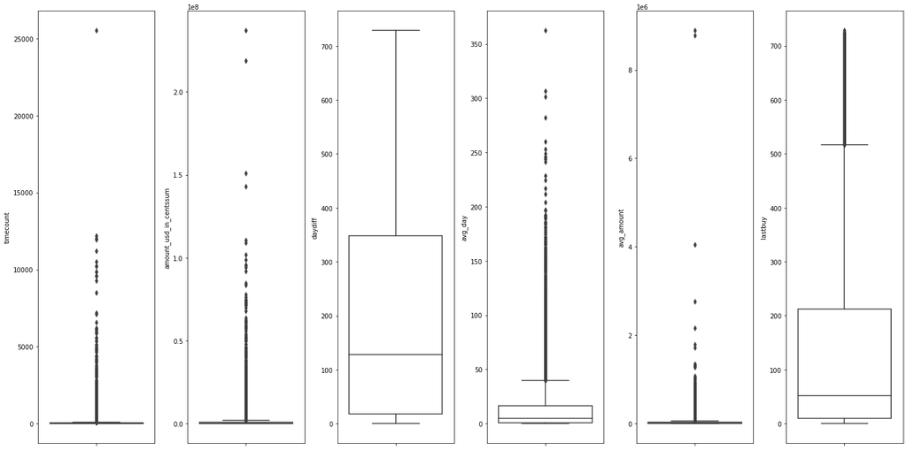

```
To check pairwise joint distribution of numeric data
```

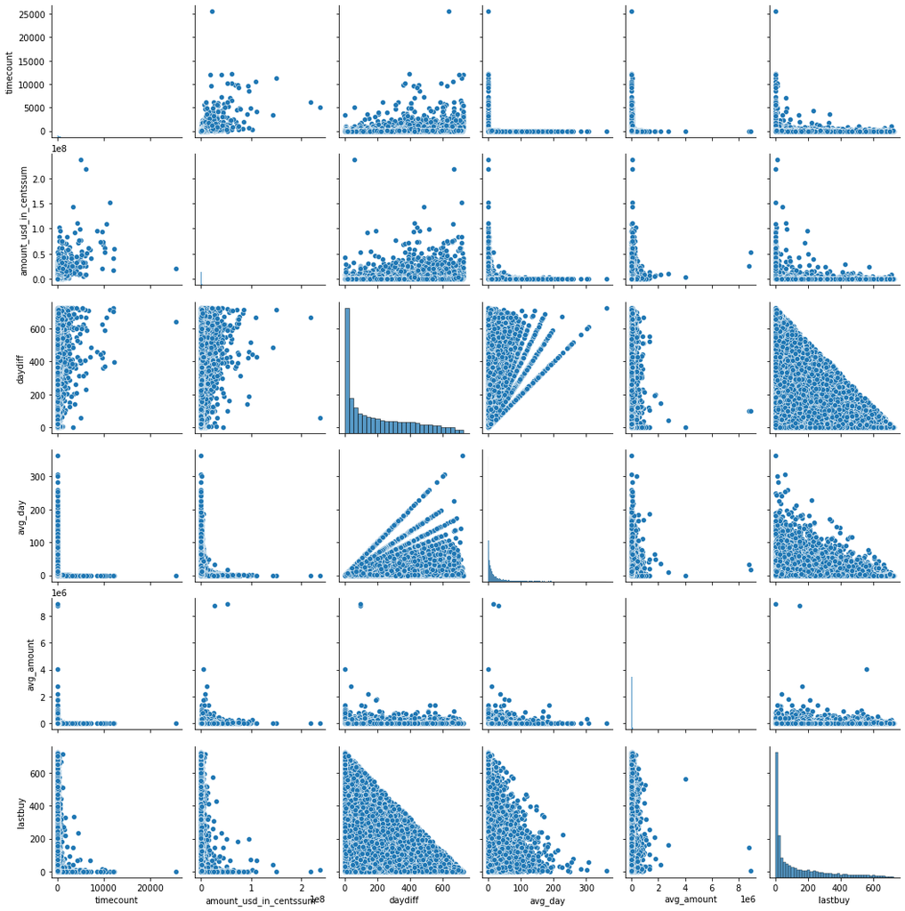

```
To check time series of numeric data  by daily, monthly and yearly frequency
```

```python
eda(data_agg[['timecount', 'amount_usd_in_centssum',
       'daydiff', 'avg_day', 'avg_amount', 'lastbuy']])
```

### EDA Findings:

1. From Distribution: spike at zero, for variable last-buy, avg-day, day-diff. May be an indicator of high transaction activity of some merchants. Need subsequent classification for validation.
1. From the box plot, we can see that outlier is widely present in the variables, and machine learning models such as KNN, K-MEANS are more sensitive to outlier, so if these models are encountered in the subsequent classification/prediction tasks, outlier needs to be eliminated.
1. Many variables are derived from several other variables, bringing about multicollinearity. Should be more selective in feature choosing.

## Type Identify

Identify the business type without specific label -> unsupervised learning for type identify -> clustering

Feature selection: Based on Recency Frequency Monetary (RFM) Model.

Key metrics:

Recency: last buy, number of days from Merchant's last purchase to 34/12/31

Frequency: avg_day, average number of days between each purchase of this merchant

Monetary: avg_amount, average amount spent by this merchant per purchase

[figure not shown]

```python
# From EDA, I found that outliers exist in the data set.
# In order to remove the outliers while preserving the characteristics of themerchants,
# I choose 95% percentale as the threshold.
# after removing the outliers, the sporadic outliers in the box plot are eliminated

data_agg_final=data_agg.loc[(data_agg['avg_amount'] < data_agg['avg_amount'].quantile(0.95))
                            & (data_agg['avg_day'] <data_agg['avg_day'].quantile(0.95))
                           & (data_agg['lastbuy'] <data_agg['lastbuy'].quantile(0.95))]
data_agg_final
```

| merchant | timeamax | timeamin | timecount | amount_usd_in_centssum | daydiff | avg_day | avg_amount | lastbuy |
| --- | --- | --- | --- | --- | --- | --- | --- | --- |
| 0002d07bba | 2034-12-15 09:56:19 | 2034-10-11 17:02:26 | 4 | 89278 | 64.666667 | 16.166667 | 22319.500000 | 15.916667 |
| 00057d4302 | 2033-08-04 04:26:40 | 2033-05-30 01:30:52 | 28 | 29521 | 66.083333 | 2.360119 | 1054.321429 | 514.125000 |
| 000bcff341 | 2033-08-09 20:18:36 | 2033-08-09 20:18:36 | 1 | 7826 | 0.000000 | 0.000000 | 7826.000000 | 508.458333 |
| 000ed1585f | 2034-12-06 15:13:44 | 2033-02-18 14:39:03 | 62 | 1647267 | 656.000000 | 10.580645 | 26568.822581 | 24.666667 |
| 000f8c3297 | 2034-12-30 16:07:05 | 2033-09-29 22:30:34 | 290 | 3455191 | 456.708333 | 1.574856 | 11914.451724 | 0.625000 |
| ... | ... | ... | ... | ... | ... | ... | ... | ... |
| ffd3284f86 | 2034-12-30 15:41:24 | 2034-12-17 04:13:32 | 10 | 80586 | 13.458333 | 1.345833 | 8058.600000 | 0.666667 |
| ffe1f6b51a | 2034-02-19 01:33:10 | 2033-06-04 00:11:12 | 53 | 281616 | 260.041667 | 4.906447 | 5313.509434 | 315.250000 |
| ffe26b900d | 2034-11-21 14:02:34 | 2033-12-22 04:01:55 | 81 | 959113 | 334.416667 | 4.128601 | 11840.901235 | 39.708333 |
| ffec05edb9 | 2034-02-14 22:34:54 | 2034-01-25 20:14:36 | 3 | 15934 | 20.083333 | 6.694444 | 5311.333333 | 319.375000 |
| fff1754102 | 2034-12-25 21:39:53 | 2033-08-08 12:15:11 | 46 | 533695 | 504.375000 | 10.964674 | 11602.065217 | 5.416667 |

12289 rows × 8 columns

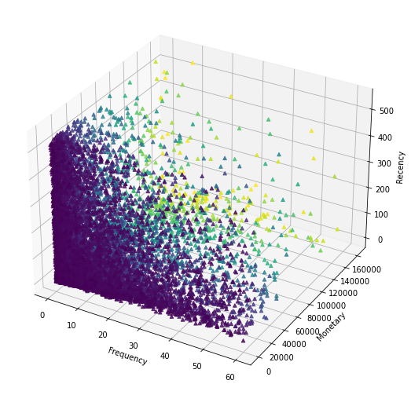

```python
# 3D data visualization for avg_day, avg_amount and last buy.
x = data_agg_final.avg_day
y = data_agg_final.avg_amount
z = data_agg_final.lastbuy
fig = plt.figure(figsize = (16, 9))
ax = plt.axes(projection ="3d")
sctt = ax.scatter3D(x, y, z,
                    alpha = 0.8,
                    c = (x + y + z),
                    marker ='^')
ax.set_xlabel('Frequency')
ax.set_ylabel('Monetary')
ax.set_zlabel('Recency')
plt.show()
```

```python
# Select features and do normalization
from sklearn.preprocessing import MinMaxScaler
data_train = data_agg_final[['avg_amount','avg_day','lastbuy']]
# fit scaler on training data
norm = MinMaxScaler().fit(data_train)

# transform training data
X_train_norm = norm.transform(data_train)
```

```python
# Select a proper K according to CH-Index, results shows that, k=4 is the best choice
from sklearn.metrics import calinski_harabasz_score
from sklearn.cluster import KMeans

best_score = -np.inf
best_k = None
best_model = None
best_cluster_assignments = None

for k in range(2, 11):
    candidate_kmeans = KMeans(n_clusters=k, n_init=100, random_state=0)
    candidate_kmeans.fit(X_train_norm)
    cluster_assignments = candidate_kmeans.predict(X_train_norm)
    score = calinski_harabasz_score(X_train_norm, cluster_assignments)

    print('k =', k, 'has CH index', score)

    if score > best_score:
        best_score = score
        best_k = k
        best_model = candidate_kmeans
        best_cluster_assignments = cluster_assignments

print('Best k within 2, 3, ..., 10 according to CH index:', best_k)
```

```
k = 2 has CH index 7555.928255209491
k = 3 has CH index 8460.464496138928
k = 4 has CH index 9073.553709386646
k = 5 has CH index 8763.436238064109
k = 6 has CH index 8487.616561222163
k = 7 has CH index 8206.551612252884
k = 8 has CH index 8054.9443523594555
k = 9 has CH index 7881.426057655245
k = 10 has CH index 7761.566633141834
Best k within 2, 3, ..., 10 according to CH index: 4
```

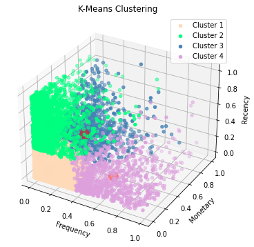

```python
kmeans = KMeans(n_clusters=4, random_state=0).fit(X_train_norm)
y_kmeans=kmeans.predict(X_train_norm)
fig = plt.figure(figsize=(10,6))
ax = fig.add_subplot(projection='3d')

ax.scatter(X_train_norm[kmeans.labels_==0, 0],
                     X_train_norm[kmeans.labels_==0, 1],X_train_norm[kmeans.labels_==0, 2],color='peachpuff',label='Cluster 1')
ax.scatter(X_train_norm[kmeans.labels_==1, 0],
                     X_train_norm[kmeans.labels_==1, 1],X_train_norm[kmeans.labels_==1, 2],color='springgreen',label='Cluster 2')
ax.scatter(X_train_norm[kmeans.labels_==2, 0],
                     X_train_norm[kmeans.labels_==2, 1],X_train_norm[kmeans.labels_==2, 2],color='steelblue',label='Cluster 3')
ax.scatter(X_train_norm[kmeans.labels_==3, 0],
                     X_train_norm[kmeans.labels_==3, 1],X_train_norm[kmeans.labels_==3, 2],color='plum',label='Cluster 4')
ax.set_title('K-Means Clustering')
ax.set_xlabel('Frequency')
ax.set_ylabel('Monetary')
ax.set_zlabel('Recency')
centers = kmeans.cluster_centers_
ax.scatter(centers[:, 0], centers[:, 1],centers[:, 2],c='red', s=200, alpha=0.5);

ax.legend()
plt.show()
```

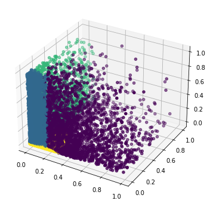

```python
from sklearn.mixture import GaussianMixture

gmm = GaussianMixture(n_components=4, random_state=0)
gmm.fit(X_train_norm)
y_kmeans_gmm=gmm.predict(X_train_norm)

fig = plt.figure(figsize=(10,6))
ax = fig.add_subplot(projection='3d')

scatter = ax.scatter(X_train_norm[:, 0],X_train_norm[:, 1],X_train_norm[:, 2],
                     c=y_kmeans_gmm)
```

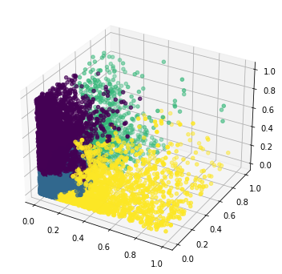

```python
from sklearn.cluster import AgglomerativeClustering
cluster = AgglomerativeClustering(n_clusters=4, affinity='euclidean', linkage='ward')
cluster.fit_predict(X_train_norm)
plt.figure(figsize=(10, 7))
fig = plt.figure(figsize=(10,6))
ax = fig.add_subplot(projection='3d')

scatter = ax.scatter(X_train_norm[:, 0],X_train_norm[:, 1],X_train_norm[:, 2],
                     c=cluster.labels_)
```

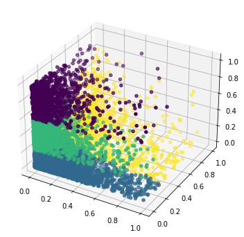

```python
from sklearn.cluster import MiniBatchKMeans
mbkmeans = MiniBatchKMeans(n_clusters=4, random_state=0)
mbkmeans.fit(X_train_norm)
y_mbkmeans=mbkmeans.predict(X_train_norm)

fig = plt.figure(figsize=(10,6))
ax = fig.add_subplot(projection='3d')

scatter = ax.scatter(X_train_norm[:, 0],X_train_norm[:, 1],X_train_norm[:, 2],
                     c=y_mbkmeans)
```

### Model Selection

K-means is my final choice.

Pros:

1. kmeans has clear bounds and corroborates with the results of other clustering algorithms.
2. Each variable is fully applied, instead of using only the y-axis and z-axis data as a classification sentence as in mini batch kmeans.
3. The logic is easier to understand and interpret, which helps to generate business insights later.

Cons:

K-means is not free lunch, it depends on the assumption that the variance of the distribution of each attribute (variable) is spherical and all variables have the same variance. The clustering effect may be poor if the hypothesis is not met.

```python
warnings.filterwarnings("ignore")
data_agg_final['label'] = None
for i in range(y_kmeans.shape[0]):
    data_agg_final['label'][i] = y_kmeans[i]
contribution_tmp = data_agg_final[['label','amount_usd_in_centssum']]
new = contribution_tmp.groupby(contribution_tmp.label).sum()
new['percent'] = (new['amount_usd_in_centssum']/new['amount_usd_in_centssum'].sum())*100
new
```

| label | amount_usd_in_centssum | percent |
| --- | --- | --- |
| 0 | 15256270269 | 76.811247 |
| 1 | 979036614 | 4.929188 |
| 2 | 252678915 | 1.272171 |
| 3 | 3374040679 | 16.987394 |

```python
np.unique(y_kmeans, return_counts=True)[1]
```

```
array([7183, 2564, 1624,  918], dtype=int64)
```

### Conclusion and Interpretation

There are 4 types of business. Type 1 (Cluster 1/Label 0): The merchants of this type have short transaction interval and low average transaction amount. It has been a relative short period of time since their last transactions. This type of merchants account for 76.8% of total transaction value. It is the fundamentals of the payment business and could be the merchants who used Stripe for payment in everyday business.

Type 2 (Cluster 2/Label 1): The merchants of this type have long transaction interval and low average transaction amount. It has also been relative a long period of time since their last transactions. This part of the transactions account for 5% of total transaction value. These merchants could be doing consumption of everyday items which would only be purchased frequently in certain time period.

Type 3 (Cluster 3/Label 2): The merchants of this type have short transaction interval and the average value of a single transaction is larger than Type 1 and Type 2. Many of the merchants haven’t been using the service recently. They account for 1.3% of total transaction value.

Type 4 (Cluster 4/Label 3): The merchants of this type have long transaction interval but the average value of a single transaction is high and it has been a short time since the last purchase. These merchants could be active Stripe user doing high value payment which were not frequently required.

## Churn Prediction

### Concrete Definition

As shown above, merchants have different categories, and each category has different transaction behaviors. Uniform classification of churn criteria (e.g., no purchase in the last month) ignores the heterogeneity of merchants and can bring great bias.

[figure not shown]

### Identify Merchants that already churn

```python
date_time_str='2034/12/31 23:59:59'
end_date = datetime.strptime(date_time_str, '%Y/%m/%d %H:%M:%S')
data_agg = transaction_all.groupby(transaction_all.merchant).agg({'time':[np.max,np.min,'count'],'amount_usd_in_cents':'sum'})
data_agg.columns = data_agg.columns.map(''.join)
data_agg['daydiff'] = ((data_agg['timeamax']-data_agg['timeamin']).astype('timedelta64[h]'))/24
data_agg['avg_day'] = data_agg['daydiff']/data_agg['timecount']
data_agg['avg_amount'] = data_agg['amount_usd_in_centssum']/data_agg['timecount']
data_agg['time_lag_inhour'] = ((end_date-data_agg['timeamax']).astype('timedelta64[h]'))
data_agg['min_to_12'] = ((end_date-data_agg['timeamin']).astype('timedelta64[h]'))
```

[output not shown]

```python
churn_set = pd.concat([data_agg,data_only_time],axis=1)
churn_set['churn_diff'] = churn_set['time_lag_inhour']-churn_set['longest_inteval']
churn_set['churn_label_now'] = None
for i in range(0,len(churn_set['churn_label_now'])):
    if churn_set['timecount'][i]<4:
        churn_set['churn_label_now'][i]=churn_set.time_lag_inhour[i]>(90*24)
    else:
         churn_set['churn_label_now'][i]=churn_set.time_lag_inhour[i]>churn_set.longest_inteval[i]
already_churned=churn_set[churn_set['churn_label_now']==True]
already_churned.head()
```

|  | timeamax | timeamin | timecount | amount_usd_in_centssum | daydiff | avg_day | avg_amount | time_lag_inhour | min_to_12 | interval_timemean | interval_timestd | interval_timecount | longest_inteval | churn_diff | churn_label_now |
| --- | --- | --- | --- | --- | --- | --- | --- | --- | --- | --- | --- | --- | --- | --- | --- |
| 0002b63b92 | 2033-05-16 20:07:57 | 2033-05-16 20:07:57 | 1 | 3379 | 0.000000 | 0.000000 | 3379.000000 | 14259.0 | 14259.0 | NaN | NaN | NaN | NaN | NaN | True |
| 00057d4302 | 2033-08-04 04:26:40 | 2033-05-30 01:30:52 | 28 | 29521 | 66.083333 | 2.360119 | 1054.321429 | 12355.0 | 13942.0 | 58.518519 | 304.071142 | 27.0 | 970.731944 | 11384.268056 | True |
| 000bcff341 | 2033-08-09 20:18:36 | 2033-08-09 20:18:36 | 1 | 7826 | 0.000000 | 0.000000 | 7826.000000 | 12219.0 | 12219.0 | NaN | NaN | NaN | NaN | NaN | True |
| 000ddbf0ca | 2033-06-02 13:25:12 | 2033-06-02 13:25:12 | 1 | 10299 | 0.000000 | 0.000000 | 10299.000000 | 13858.0 | 13858.0 | NaN | NaN | NaN | NaN | NaN | True |
| 001f7b7a4f | 2034-03-02 19:46:05 | 2034-03-02 19:46:05 | 1 | 6444 | 0.000000 | 0.000000 | 6444.000000 | 7300.0 | 7300.0 | NaN | NaN | NaN | NaN | NaN | True |

```python
still_active_at12 = churn_set[churn_set['churn_label_now']==False]
```

### Churn Prediction

Clarification: Near future is in the next three month.

Prediction Process:

Because of the lack of future data as the training set, the time was pulled back 3 months and use the tags of active users in September who churned/or not in December as the training data. Using the trained model for prediction of December active user data.

Assumption:

Recent user churn behavior has maintained the same pattern

```python
data_only_time = data.sort_values(by=['merchant', 'time']).reset_index(drop=True)
```

```python
date_time_str='2034/09/30 23:59:59'
end_date = datetime.strptime(date_time_str, '%Y/%m/%d %H:%M:%S')
transaction_be4_10 = data[data['time']<end_date]
data_only_time_9 = transaction_be4_10.sort_values(by=['merchant', 'time']).reset_index(drop=True)
data_only_time_9 = data_only_time_9[['merchant', 'time']]
data_only_time_9['nexttime']=data_only_time_9['time'].shift(-1)
data_only_time_9['nextid']=data_only_time_9['merchant'].shift(-1)
data_only_time_9['interval_time']=((data_only_time_9['nexttime']-data_only_time_9['time']).astype('timedelta64[h]'))
data_only_time_9['interval_id']=(data_only_time_9['nextid']==data_only_time_9['merchant'])
data_only_time_9=data_only_time_9[data_only_time_9['interval_id']==True]
data_only_time_9.head(10)
data_only_time_9 = data_only_time_9.groupby(data_only_time_9.merchant).agg({'interval_time':[np.mean,np.std,'count']})
data_only_time_9.columns = data_only_time_9.columns.map(''.join)
data_only_time_9['longest_inteval']=data_only_time_9['interval_timemean']+3*data_only_time_9['interval_timestd']
data_only_time_9.head(20)
```

| merchant | interval_timemean | interval_timestd | interval_timecount | longest_inteval |
| --- | --- | --- | --- | --- |
| 00057d4302 | 58.518519 | 304.071142 | 27 | 970.731944 |
| 000ed1585f | 226.758621 | 247.937549 | 58 | 970.571269 |
| 000f8c3297 | 46.224599 | 70.682258 | 187 | 258.271372 |
| 0020aefbd9 | 543.000000 | NaN | 1 | NaN |
| 0026f256ac | 302.714286 | 131.915016 | 7 | 698.459334 |
| 002a66c0e1 | 87.859155 | 100.980096 | 71 | 390.799444 |
| 0037a192b4 | 1424.333333 | 1011.325599 | 6 | 4458.310130 |
| 003d24c5d3 | 180.800000 | 292.765606 | 5 | 1059.096818 |
| 003d5fe4f1 | 448.000000 | NaN | 1 | NaN |
| 0042aadfdf | 17.146853 | 76.635589 | 143 | 247.053620 |
| 0047f556b5 | 542.500000 | 311.834091 | 2 | 1478.002272 |
| 004a994585 | 360.727273 | 527.413707 | 11 | 1942.968393 |
| 004d02cb10 | 106.300000 | 171.012230 | 30 | 619.336690 |
| 0052daeb66 | 42.000000 | 80.676308 | 4 | 284.028924 |
| 00575c7901 | 0.997054 | 2.144141 | 4752 | 7.429476 |
| 005c218139 | 79.333333 | 96.996564 | 3 | 370.323024 |
| 005e8bb6fb | 2.142827 | 24.844515 | 4810 | 76.676372 |
| 0063ff0c6b | 377.961538 | 1432.175310 | 26 | 4674.487468 |
| 007364b02a | 2832.500000 | 542.350901 | 2 | 4459.552704 |
| 0082de98e9 | 37.352941 | 69.695715 | 17 | 246.440085 |

```python
data_agg_9 = transaction_be4_10.groupby(transaction_be4_10.merchant).agg({'time':[np.max,np.min,'count'],'amount_usd_in_cents':'sum'})
data_agg_9.columns = data_agg_9.columns.map(''.join)
data_agg_9['daydiff'] = ((data_agg_9['timeamax']-data_agg_9['timeamin']).astype('timedelta64[h]'))/24
data_agg_9['avg_day'] = data_agg_9['daydiff']/data_agg_9['timecount']
data_agg_9['avg_amount'] = data_agg_9['amount_usd_in_centssum']/data_agg_9['timecount']
data_agg_9['time_lag_inhour'] = ((end_date-data_agg_9['timeamax']).astype('timedelta64[h]'))
data_agg_9['min_to_9'] = ((end_date-data_agg_9['timeamin']).astype('timedelta64[h]'))
data_agg_9.head(10)
```

| merchant | timeamax | timeamin | timecount | amount_usd_in_centssum | daydiff | avg_day | avg_amount | time_lag_inhour | min_to_9 |
| --- | --- | --- | --- | --- | --- | --- | --- | --- | --- |
| 0002b63b92 | 2033-05-16 20:07:57 | 2033-05-16 20:07:57 | 1 | 3379 | 0.000000 | 0.000000 | 3379.000000 | 12051.0 | 12051.0 |
| 00057d4302 | 2033-08-04 04:26:40 | 2033-05-30 01:30:52 | 28 | 29521 | 66.083333 | 2.360119 | 1054.321429 | 10147.0 | 11734.0 |
| 000bcff341 | 2033-08-09 20:18:36 | 2033-08-09 20:18:36 | 1 | 7826 | 0.000000 | 0.000000 | 7826.000000 | 10011.0 | 10011.0 |
| 000ddbf0ca | 2033-06-02 13:25:12 | 2033-06-02 13:25:12 | 1 | 10299 | 0.000000 | 0.000000 | 10299.000000 | 11650.0 | 11650.0 |
| 000ed1585f | 2034-08-21 21:08:35 | 2033-02-18 14:39:03 | 59 | 1575472 | 549.250000 | 9.309322 | 26702.915254 | 962.0 | 14145.0 |
| 000f8c3297 | 2034-09-28 23:23:45 | 2033-09-29 22:30:34 | 188 | 2130584 | 364.000000 | 1.936170 | 11332.893617 | 48.0 | 8785.0 |
| 001f7b7a4f | 2034-03-02 19:46:05 | 2034-03-02 19:46:05 | 1 | 6444 | 0.000000 | 0.000000 | 6444.000000 | 5092.0 | 5092.0 |
| 0020aefbd9 | 2034-06-22 13:41:11 | 2034-05-30 21:55:06 | 2 | 13004 | 22.625000 | 11.312500 | 6502.000000 | 2410.0 | 2954.0 |
| 0026f256ac | 2033-09-15 01:17:32 | 2033-06-18 14:58:07 | 8 | 250878 | 88.416667 | 11.052083 | 31359.750000 | 9142.0 | 11265.0 |
| 002a66c0e1 | 2034-09-30 14:00:51 | 2034-01-12 03:29:49 | 72 | 2545306 | 261.416667 | 3.630787 | 35351.472222 | 9.0 | 6284.0 |

```python
churn_set_9 = pd.concat([data_agg_9,data_only_time_9],axis=1)
churn_set_9['churn_diff'] = churn_set_9['time_lag_inhour']-churn_set_9['longest_inteval']
churn_set_9.head(10)
```

|  | timeamax | timeamin | timecount | amount_usd_in_centssum | daydiff | avg_day | avg_amount | time_lag_inhour | min_to_9 | interval_timemean | interval_timestd | interval_timecount | longest_inteval | churn_diff |
| --- | --- | --- | --- | --- | --- | --- | --- | --- | --- | --- | --- | --- | --- | --- |
| 0002b63b92 | 2033-05-16 20:07:57 | 2033-05-16 20:07:57 | 1 | 3379 | 0.000000 | 0.000000 | 3379.000000 | 12051.0 | 12051.0 | NaN | NaN | NaN | NaN | NaN |
| 00057d4302 | 2033-08-04 04:26:40 | 2033-05-30 01:30:52 | 28 | 29521 | 66.083333 | 2.360119 | 1054.321429 | 10147.0 | 11734.0 | 58.518519 | 304.071142 | 27.0 | 970.731944 | 9176.268056 |
| 000bcff341 | 2033-08-09 20:18:36 | 2033-08-09 20:18:36 | 1 | 7826 | 0.000000 | 0.000000 | 7826.000000 | 10011.0 | 10011.0 | NaN | NaN | NaN | NaN | NaN |
| 000ddbf0ca | 2033-06-02 13:25:12 | 2033-06-02 13:25:12 | 1 | 10299 | 0.000000 | 0.000000 | 10299.000000 | 11650.0 | 11650.0 | NaN | NaN | NaN | NaN | NaN |
| 000ed1585f | 2034-08-21 21:08:35 | 2033-02-18 14:39:03 | 59 | 1575472 | 549.250000 | 9.309322 | 26702.915254 | 962.0 | 14145.0 | 226.758621 | 247.937549 | 58.0 | 970.571269 | -8.571269 |
| 000f8c3297 | 2034-09-28 23:23:45 | 2033-09-29 22:30:34 | 188 | 2130584 | 364.000000 | 1.936170 | 11332.893617 | 48.0 | 8785.0 | 46.224599 | 70.682258 | 187.0 | 258.271372 | -210.271372 |
| 001f7b7a4f | 2034-03-02 19:46:05 | 2034-03-02 19:46:05 | 1 | 6444 | 0.000000 | 0.000000 | 6444.000000 | 5092.0 | 5092.0 | NaN | NaN | NaN | NaN | NaN |
| 0020aefbd9 | 2034-06-22 13:41:11 | 2034-05-30 21:55:06 | 2 | 13004 | 22.625000 | 11.312500 | 6502.000000 | 2410.0 | 2954.0 | 543.000000 | NaN | 1.0 | NaN | NaN |
| 0026f256ac | 2033-09-15 01:17:32 | 2033-06-18 14:58:07 | 8 | 250878 | 88.416667 | 11.052083 | 31359.750000 | 9142.0 | 11265.0 | 302.714286 | 131.915016 | 7.0 | 698.459334 | 8443.540666 |
| 002a66c0e1 | 2034-09-30 14:00:51 | 2034-01-12 03:29:49 | 72 | 2545306 | 261.416667 | 3.630787 | 35351.472222 | 9.0 | 6284.0 | 87.859155 | 100.980096 | 71.0 | 390.799444 | -381.799444 |

```python
churn_set_9['churn_label'] = None
for i in range(0,len(churn_set_9['churn_label'])):
    if churn_set_9['timecount'][i]<4:
        churn_set_9['churn_label'][i]=churn_set_9.time_lag_inhour[i]>(90*24)
    else:
         churn_set_9['churn_label'][i]=churn_set_9.time_lag_inhour[i]>churn_set_9.longest_inteval[i]
temp=churn_set_9[churn_set_9['churn_label']==False]
temp.shape
```

```
(6828, 15)
```

```python
date_time_str='2034/12/31 23:59:59'
date_time_str_0='2034/9/30 23:59:59'
end_date = datetime.strptime(date_time_str, '%Y/%m/%d %H:%M:%S')
start_date = datetime.strptime(date_time_str_0, '%Y/%m/%d %H:%M:%S')
transaction_be4_12 = data[data['time']<end_date]
data = data[data['time']>start_date]
data_only_time = transaction_be4_12.sort_values(by=['merchant', 'time']).reset_index(drop=True)
data_only_time = data_only_time[['merchant', 'time']]
data_only_time['nexttime']=data_only_time['time'].shift(-1)
data_only_time['nextid']=data_only_time['merchant'].shift(-1)
data_only_time['interval_time']=((data_only_time['nexttime']-data_only_time['time']).astype('timedelta64[h]'))
data_only_time['interval_id']=(data_only_time['nextid']==data_only_time['merchant'])
data_only_time=data_only_time[data_only_time['interval_id']==True]
data_only_time.head(10)
data_only_time = data_only_time.groupby(data_only_time.merchant).agg({'interval_time':[np.mean,np.std,'count']})
data_only_time.columns = data_only_time.columns.map(''.join)
data_only_time['longest_inteval']=data_only_time['interval_timemean']+3*data_only_time['interval_timestd']
data_only_time.head(20)
```

| merchant | interval_timemean | interval_timestd | interval_timecount | longest_inteval |
| --- | --- | --- | --- | --- |
| 0002d07bba | 517.000000 | 328.281891 | 3 | 1501.845673 |
| 00057d4302 | 58.518519 | 304.071142 | 27 | 970.731944 |
| 000ed1585f | 257.590164 | 362.286782 | 61 | 1344.450511 |
| 000f8c3297 | 37.442907 | 61.952191 | 289 | 223.299480 |
| 0020aefbd9 | 543.000000 | NaN | 1 | NaN |
| 0026f256ac | 302.714286 | 131.915016 | 7 | 698.459334 |
| 002a66c0e1 | 82.841584 | 96.847894 | 101 | 373.385267 |
| 0037a192b4 | 1424.333333 | 1011.325599 | 6 | 4458.310130 |
| 003d24c5d3 | 480.285714 | 623.673717 | 7 | 2351.306864 |
| 003d5fe4f1 | 331.250000 | 236.622514 | 8 | 1041.117543 |
| 0042aadfdf | 17.146853 | 76.635589 | 143 | 247.053620 |
| 0047f556b5 | 542.500000 | 311.834091 | 2 | 1478.002272 |
| 004a994585 | 358.923077 | 481.785994 | 13 | 1804.281058 |
| 004d02cb10 | 106.300000 | 171.012230 | 30 | 619.336690 |
| 0052daeb66 | 42.000000 | 80.676308 | 4 | 284.028924 |
| 00575c7901 | 0.578355 | 1.629020 | 9859 | 5.465413 |
| 005c218139 | 79.333333 | 96.996564 | 3 | 370.323024 |
| 005e8bb6fb | 2.238174 | 25.069932 | 4820 | 77.447969 |
| 0063ff0c6b | 425.407407 | 1425.838923 | 27 | 4702.924177 |
| 007364b02a | 2832.500000 | 542.350901 | 2 | 4459.552704 |

```python
data_agg = transaction_be4_12.groupby(transaction_be4_12.merchant).agg({'time':[np.max,np.min,'count'],'amount_usd_in_cents':'sum'})
data_agg.columns = data_agg.columns.map(''.join)
data_agg['daydiff'] = ((data_agg['timeamax']-data_agg['timeamin']).astype('timedelta64[h]'))/24
data_agg['avg_day'] = data_agg['daydiff']/data_agg['timecount']
data_agg['avg_amount'] = data_agg['amount_usd_in_centssum']/data_agg['timecount']
data_agg['time_lag_inhour'] = ((end_date-data_agg['timeamax']).astype('timedelta64[h]'))
data_agg['min_to_12'] = ((end_date-data_agg['timeamin']).astype('timedelta64[h]'))
data_agg.head(10)
```

| merchant | timeamax | timeamin | timecount | amount_usd_in_centssum | daydiff | avg_day | avg_amount | time_lag_inhour | min_to_12 |
| --- | --- | --- | --- | --- | --- | --- | --- | --- | --- |
| 0002b63b92 | 2033-05-16 20:07:57 | 2033-05-16 20:07:57 | 1 | 3379 | 0.000000 | 0.000000 | 3379.000000 | 14259.0 | 14259.0 |
| 0002d07bba | 2034-12-15 09:56:19 | 2034-10-11 17:02:26 | 4 | 89278 | 64.666667 | 16.166667 | 22319.500000 | 398.0 | 1950.0 |
| 00057d4302 | 2033-08-04 04:26:40 | 2033-05-30 01:30:52 | 28 | 29521 | 66.083333 | 2.360119 | 1054.321429 | 12355.0 | 13942.0 |
| 000bcff341 | 2033-08-09 20:18:36 | 2033-08-09 20:18:36 | 1 | 7826 | 0.000000 | 0.000000 | 7826.000000 | 12219.0 | 12219.0 |
| 000ddbf0ca | 2033-06-02 13:25:12 | 2033-06-02 13:25:12 | 1 | 10299 | 0.000000 | 0.000000 | 10299.000000 | 13858.0 | 13858.0 |
| 000ed1585f | 2034-12-06 15:13:44 | 2033-02-18 14:39:03 | 62 | 1647267 | 656.000000 | 10.580645 | 26568.822581 | 608.0 | 16353.0 |
| 000f8c3297 | 2034-12-30 16:07:05 | 2033-09-29 22:30:34 | 290 | 3455191 | 456.708333 | 1.574856 | 11914.451724 | 31.0 | 10993.0 |
| 001f7b7a4f | 2034-03-02 19:46:05 | 2034-03-02 19:46:05 | 1 | 6444 | 0.000000 | 0.000000 | 6444.000000 | 7300.0 | 7300.0 |
| 0020aefbd9 | 2034-06-22 13:41:11 | 2034-05-30 21:55:06 | 2 | 13004 | 22.625000 | 11.312500 | 6502.000000 | 4618.0 | 5162.0 |
| 0026f256ac | 2033-09-15 01:17:32 | 2033-06-18 14:58:07 | 8 | 250878 | 88.416667 | 11.052083 | 31359.750000 | 11350.0 | 13473.0 |

```python
churn_set = pd.concat([data_agg,data_only_time],axis=1)
churn_set['churn_diff'] = churn_set['time_lag_inhour']-churn_set['longest_inteval']
tmp=churn_set[churn_set['timecount']==0]
tmp.shape
```

```
(0, 14)
```

```python
churn_set['churn_label_12'] = None
for i in range(0,len(churn_set['churn_label_12'])):
    if churn_set['timecount'][i]<4:
        churn_set['churn_label_12'][i]=churn_set.time_lag_inhour[i]>(90*24)
    else:
         churn_set['churn_label_12'][i]=churn_set.time_lag_inhour[i]>churn_set.longest_inteval[i]
temp=churn_set[churn_set['churn_label_12']==False]
temp.shape
```

```
(7800, 15)
```

```python
churn_set.columns
```

```
Index(['timeamax', 'timeamin', 'timecount', 'amount_usd_in_centssum',
       'daydiff', 'avg_day', 'avg_amount', 'time_lag_inhour', 'min_to_12',
       'interval_timemean', 'interval_timestd', 'interval_timecount',
       'longest_inteval', 'churn_diff', 'churn_label_12'],
      dtype='object')
```

```python
active_9=churn_set_9[churn_set_9['churn_label']==False]
active_9.shape
label_12=churn_set[['churn_label_12']]
to_predict=active_9.join(label_12)
to_predict.head(12)
tmp=to_predict[['churn_label','churn_label_12']]
a=tmp.groupby(tmp.churn_label_12).agg('count')
a
```

| churn_label_12 | churn_label |
| --- | --- |
| False | 5102 |
| True | 1726 |

```python
to_predict.head(100)
```

|  | timeamax | timeamin | timecount | amount_usd_in_centssum | daydiff | avg_day | avg_amount | time_lag_inhour | min_to_9 | interval_timemean | interval_timestd | interval_timecount | longest_inteval | churn_diff | churn_label | churn_label_12 |
| --- | --- | --- | --- | --- | --- | --- | --- | --- | --- | --- | --- | --- | --- | --- | --- | --- |
| 000ed1585f | 2034-08-21 21:08:35 | 2033-02-18 14:39:03 | 59 | 1575472 | 549.250000 | 9.309322 | 26702.915254 | 962.0 | 14145.0 | 226.758621 | 247.937549 | 58.0 | 970.571269 | -8.571269 | False | False |
| 000f8c3297 | 2034-09-28 23:23:45 | 2033-09-29 22:30:34 | 188 | 2130584 | 364.000000 | 1.936170 | 11332.893617 | 48.0 | 8785.0 | 46.224599 | 70.682258 | 187.0 | 258.271372 | -210.271372 | False | False |
| 002a66c0e1 | 2034-09-30 14:00:51 | 2034-01-12 03:29:49 | 72 | 2545306 | 261.416667 | 3.630787 | 35351.472222 | 9.0 | 6284.0 | 87.859155 | 100.980096 | 71.0 | 390.799444 | -381.799444 | False | False |
| 0037a192b4 | 2034-09-21 00:53:24 | 2033-09-29 20:24:09 | 7 | 95113 | 356.166667 | 50.880952 | 13587.571429 | 239.0 | 8787.0 | 1424.333333 | 1011.325599 | 6.0 | 4458.310130 | -4219.310130 | False | False |
| 003d24c5d3 | 2034-08-29 11:26:38 | 2034-07-22 16:42:30 | 6 | 51115 | 37.750000 | 6.291667 | 8519.166667 | 780.0 | 1687.0 | 180.800000 | 292.765606 | 5.0 | 1059.096818 | -279.096818 | False | False |
| ... | ... | ... | ... | ... | ... | ... | ... | ... | ... | ... | ... | ... | ... | ... | ... | ... |
| 03bd2d6a2b | 2034-09-05 20:29:22 | 2034-09-05 20:29:22 | 1 | 4707 | 0.000000 | 0.000000 | 4707.000000 | 603.0 | 603.0 | NaN | NaN | NaN | NaN | NaN | False | False |
| 03c0cdb80d | 2034-09-16 21:48:59 | 2034-09-16 21:48:59 | 1 | 17618 | 0.000000 | 0.000000 | 17618.000000 | 338.0 | 338.0 | NaN | NaN | NaN | NaN | NaN | False | True |
| 03c4d7917f | 2034-08-05 03:01:49 | 2033-06-03 20:33:57 | 6 | 1394641 | 427.250000 | 71.208333 | 232440.166667 | 1364.0 | 11619.0 | 2050.400000 | 3469.329517 | 5.0 | 12458.388552 | -11094.388552 | False | False |
| 03cd2d8d46 | 2034-09-08 19:49:39 | 2033-09-18 20:37:43 | 8 | 453772 | 354.958333 | 44.369792 | 56721.500000 | 532.0 | 9051.0 | 1216.714286 | 2817.630666 | 7.0 | 9669.606284 | -9137.606284 | False | False |
| 03d5e128b9 | 2034-09-08 00:53:00 | 2034-08-04 20:11:59 | 2 | 15337 | 34.166667 | 17.083333 | 7668.500000 | 551.0 | 1371.0 | 820.000000 | NaN | 1.0 | NaN | NaN | False | False |

100 rows × 16 columns

```python
from sklearn.model_selection import train_test_split
to_predict_with_fill=to_predict
to_predict_with_fill['interval_timemean']=to_predict_with_fill['interval_timemean'].fillna(99999)
to_predict_with_fill['interval_timestd']=to_predict_with_fill['interval_timestd'].fillna(99999)
to_predict_with_fill['interval_timecount']=to_predict_with_fill['interval_timecount'].fillna(99999)
to_predict_with_fill['longest_inteval']=to_predict_with_fill['longest_inteval'].fillna(99999)
to_predict_with_fill['churn_diff']=to_predict_with_fill['churn_diff'].fillna(99999)
X_1=to_predict_with_fill.iloc[:,[2,3,4,5,6,7,8,9,10,11,12,13]]
y_1=to_predict_with_fill.churn_label_12.astype(int)
X_train_1, X_test_1, y_train_1, y_test_1 = train_test_split(X_1, y_1, test_size=0.3, random_state=42, stratify=y_1)
```

```python
from imblearn.over_sampling import SMOTE
smt = SMOTE()
X_train_1_sm,y_train_1sm=smt.fit_resample(X_train_1,y_train_1)
```

```python
from sklearn.linear_model import LogisticRegression
from sklearn.neighbors import KNeighborsClassifier
from sklearn.svm import SVC
from sklearn.ensemble import RandomForestClassifier
from sklearn.naive_bayes import GaussianNB
from xgboost import XGBClassifier
from sklearn import model_selection
from sklearn.utils import class_weight
from sklearn.metrics import classification_report
from sklearn.metrics import confusion_matrix
import numpy as np
import pandas as pd
warnings.filterwarnings("ignore")
def run_exps(X_train: pd.DataFrame , y_train: pd.DataFrame, X_test: pd.DataFrame, y_test: pd.DataFrame) -> pd.DataFrame:
    dfs = []
    models = [
          ('LogReg', LogisticRegression()),
          ('RF', RandomForestClassifier()),
          ('KNN', KNeighborsClassifier()),
          ('SVM', SVC()),
          ('GNB', GaussianNB()),
          ('XGB', XGBClassifier())
        ]
    results = []
    names = []
    scoring = ['accuracy', 'precision_weighted', 'recall_weighted', 'f1_weighted', 'roc_auc']
    target_names = ['Not Churn', 'Churn']
    for name, model in models:
        kfold = model_selection.KFold(n_splits=5, shuffle=True, random_state=90210)
        cv_results = model_selection.cross_validate(model, X_train, y_train, cv=kfold, scoring=scoring)
        clf = model.fit(X_train, y_train)
        y_pred = clf.predict(X_test)
        print(name)
        print(classification_report(y_test, y_pred, target_names=target_names))

    results.append(cv_results)
    names.append(name)
    this_df = pd.DataFrame(cv_results)
    this_df['model'] = name
    dfs.append(this_df)
    final = pd.concat(dfs, ignore_index=True)
    return final
```

```python
warnings.filterwarnings("ignore")
res = run_exps(X_train_1_sm,y_train_1sm,X_test_1,y_test_1)
res
```

```
LogReg
              precision    recall  f1-score   support

   Not Churn       0.83      0.85      0.84      1531
       Churn       0.52      0.48      0.50       518

    accuracy                           0.76      2049
   macro avg       0.67      0.67      0.67      2049
weighted avg       0.75      0.76      0.75      2049

RF
              precision    recall  f1-score   support

   Not Churn       0.86      0.74      0.80      1531
       Churn       0.45      0.63      0.53       518

    accuracy                           0.71      2049
   macro avg       0.65      0.69      0.66      2049
weighted avg       0.75      0.71      0.73      2049

KNN
              precision    recall  f1-score   support

   Not Churn       0.81      0.65      0.72      1531
       Churn       0.34      0.54      0.42       518

    accuracy                           0.62      2049
   macro avg       0.57      0.59      0.57      2049
weighted avg       0.69      0.62      0.64      2049

SVM
              precision    recall  f1-score   support

   Not Churn       0.83      0.42      0.56      1531
       Churn       0.30      0.75      0.43       518

    accuracy                           0.50      2049
   macro avg       0.57      0.58      0.49      2049
weighted avg       0.70      0.50      0.53      2049

```

[output cut: 10 more lines]

[output not shown]

|  | fit_time | score_time | test_accuracy | test_precision_weighted | test_recall_weighted | test_f1_weighted | test_roc_auc | model |
| --- | --- | --- | --- | --- | --- | --- | --- | --- |
| 0 | 0.502486 | 0.013963 | 0.792862 | 0.795881 | 0.792862 | 0.792342 | 0.871133 | XGB |
| 1 | 0.493115 | 0.013963 | 0.787264 | 0.789242 | 0.787264 | 0.786857 | 0.865625 | XGB |
| 2 | 0.489817 | 0.010979 | 0.801821 | 0.802534 | 0.801821 | 0.801513 | 0.879998 | XGB |
| 3 | 0.472009 | 0.013982 | 0.790616 | 0.793212 | 0.790616 | 0.790562 | 0.859793 | XGB |
| 4 | 0.497958 | 0.012986 | 0.795518 | 0.796875 | 0.795518 | 0.795217 | 0.868107 | XGB |

### Prediction Model Selection

```python
to_pred = still_active_at12.iloc[:,[2,3,4,5,6,7,8,9,10,11,12,13]]
```

[output not shown]

```python
from xgboost import XGBClassifier
model = XGBClassifier()
clf = model.fit(X_train_1_sm,y_train_1sm)
predict = clf.predict_proba(to_pred)
predict
```

[output not shown]

```
array([[0.15707201, 0.842928  ],
       [0.50024956, 0.49975044],
       [0.4115374 , 0.5884626 ],
       ...,
       [0.99246824, 0.00753178],
       [0.5249008 , 0.4750992 ],
       [0.99876904, 0.00123097]], dtype=float32)
```

```python
to_pred['churn_prob'] = None
for i in range(predict.shape[0]):
    to_pred['churn_prob'][i] = predict[i][1]
sort_by_prob_desc=to_pred.sort_values(by=['churn_prob'], ascending=False)
sort_by_prob_desc.head(100)
```

|  | timecount | amount_usd_in_centssum | daydiff | avg_day | avg_amount | time_lag_inhour | min_to_12 | interval_timemean | interval_timestd | interval_timecount | longest_inteval | churn_diff | churn_prob |
| --- | --- | --- | --- | --- | --- | --- | --- | --- | --- | --- | --- | --- | --- |
| b583972b34 | 2777 | 15507891 | 410.166667 | 0.147701 | 5584.404393 | 20.0 | 9864.0 | 3.095101 | 6.147112 | 2776.0 | 21.536438 | -1.536438 | 0.996372 |
| 48008cb383 | 2652 | 13491460 | 416.083333 | 0.156894 | 5087.277526 | 19.0 | 10005.0 | 3.393814 | 9.055570 | 2651.0 | 30.560523 | -11.560523 | 0.996132 |
| 7afb593dd0 | 86 | 2818072 | 540.833333 | 6.288760 | 32768.279070 | 2426.0 | 15406.0 | 152.576471 | 1079.472119 | 85.0 | 3390.992829 | -964.992829 | 0.995882 |
| fae77cd687 | 2677 | 17024110 | 449.250000 | 0.167818 | 6359.398581 | 20.0 | 10803.0 | 3.584828 | 6.098805 | 2676.0 | 21.881242 | -1.881242 | 0.99504 |
| f11205719b | 2559 | 12968240 | 341.291667 | 0.133369 | 5067.698320 | 19.0 | 8211.0 | 2.750195 | 6.109462 | 2558.0 | 21.078582 | -2.078582 | 0.994982 |
| ... | ... | ... | ... | ... | ... | ... | ... | ... | ... | ... | ... | ... | ... |
| 07bca2628f | 8 | 48698 | 265.958333 | 33.244792 | 6087.250000 | 7031.0 | 13415.0 | 911.714286 | 2166.923296 | 7.0 | 7412.484174 | -381.484174 | 0.947905 |
| 55935d25c9 | 3 | 70166 | 33.875000 | 11.291667 | 23388.666667 | 982.0 | 1796.0 | 406.000000 | 288.499567 | 2.0 | 1271.498700 | -289.498700 | 0.947743 |
| 0ac14a7806 | 1 | 6642 | 0.000000 | 0.000000 | 6642.000000 | 1475.0 | 1475.0 | NaN | NaN | NaN | NaN | NaN | 0.947664 |
| cda5ee377d | 3 | 17638 | 41.958333 | 13.986111 | 5879.333333 | 291.0 | 1299.0 | 503.000000 | 236.173665 | 2.0 | 1211.520995 | -920.520995 | 0.947598 |
| 1e59e29ddb | 1811 | 23690193 | 375.958333 | 0.207597 | 13081.277195 | 18.0 | 9042.0 | 4.517680 | 6.408774 | 1810.0 | 23.744000 | -5.744000 | 0.947454 |

100 rows × 13 columns

### Business Value

By knowing which clients are at the highest risk of leaving, we can better target our rescue efforts. For example, we can reach out to these clients with a marketing campaign, reminding them that they haven’t used service from us in a while, or even offering them a benefit.

In addition to knowing which clients to target, we can use the churn model to calculate the maximum benefit price that is still worthwhile. For example, if we know that the estimated probability of a particular client leaving is 10% and their annual revenue is 100, the expected value of future annual revenue is $90. Therefore, an offer that typically reduces the probability of leaving to 5 percent will be worthwhile for this client, so long as it does not cost more than 5.